# Data Viz and Analysis of Olympic Data

Chad Himes

2026-04-27

# Preliminary Questions:

- How much have the Olympics grown over time?
- How has the gender of athletes changes over time?
  - Are some seasons more equal than others?
- Which countries have the most sucess at the Olympics?
  - Look into overall medal counts
  - Does location change who wins the Winter vs Summer?
  - What country has the most medals per million people?
  - Does the economic success (GDP) of a country align with their success?

# How has he Olympics grown?

One of the best ways to measure the growth of the Olympics is to see how the number of medals has changed over the years. As shown in this graph, over time the Olympics have steadily grown over the years, even when the Olympics were split into their respective seasons in 1993.

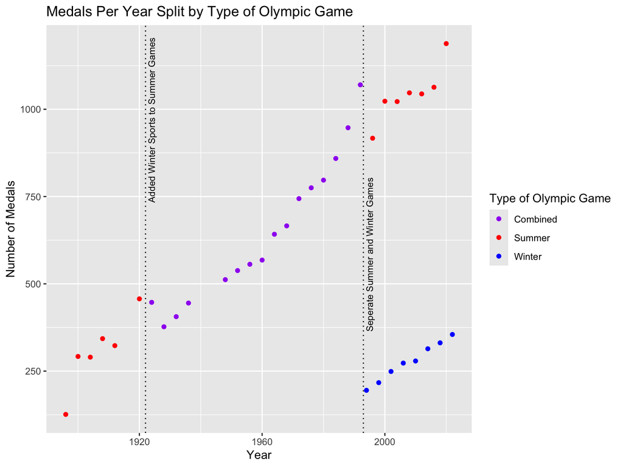

# Male/Female Gender Split

Using Olympic medal data to show the gender split in the olympics over time.

[interactive chart not shown]

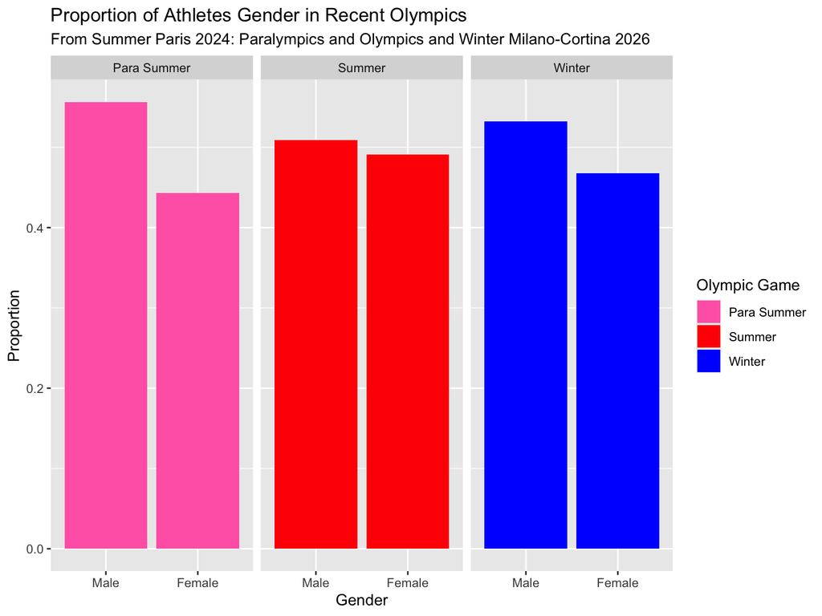

# In recent year, what countries win the most medals?

Let’s compare the top 10 countries by total medal count for the most recent Olympics (Paris 2024 and Milano-Cortina 2026)

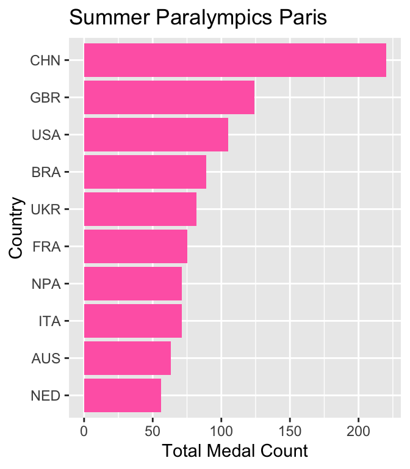

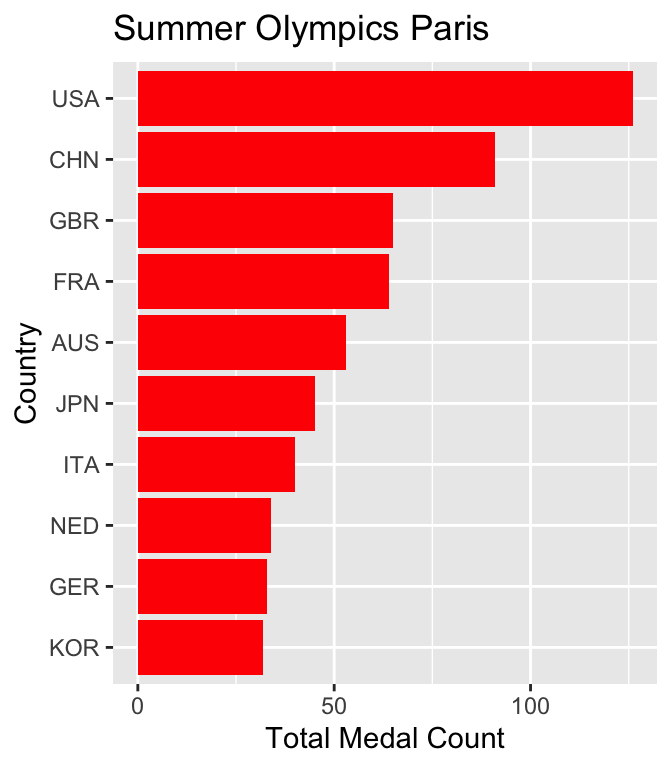

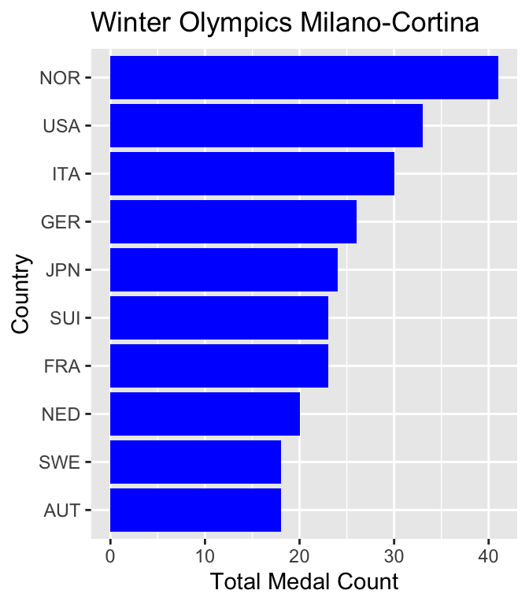

# Does location matter when it comes to winning medals?

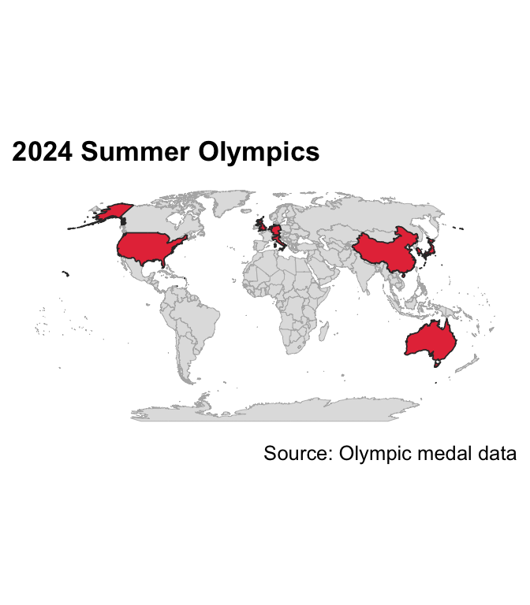

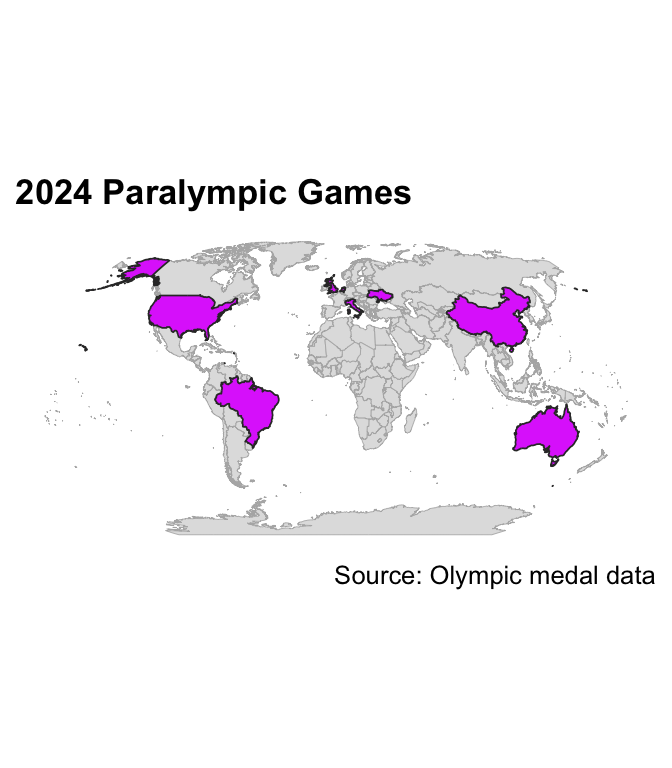

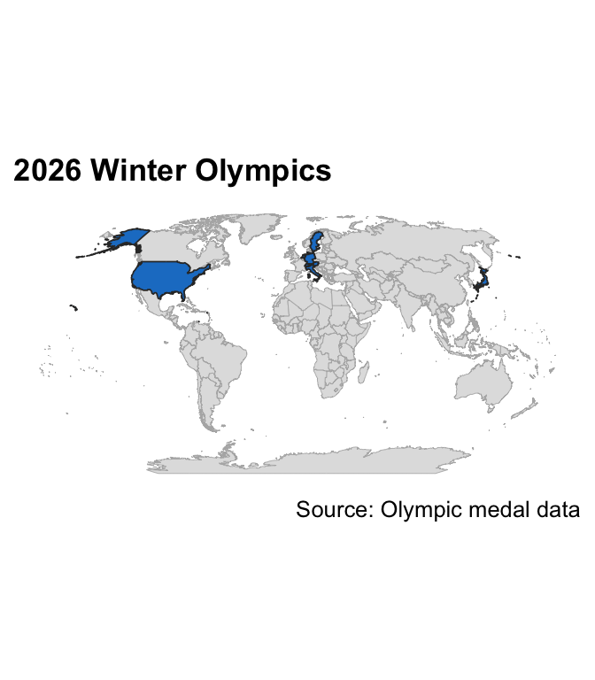

# Medals per Million people

Looking at total medal count is unfair since gives a larger advantage towards larger countries that can send more people. Using population data, I looked at which countries had the most medals per million people.

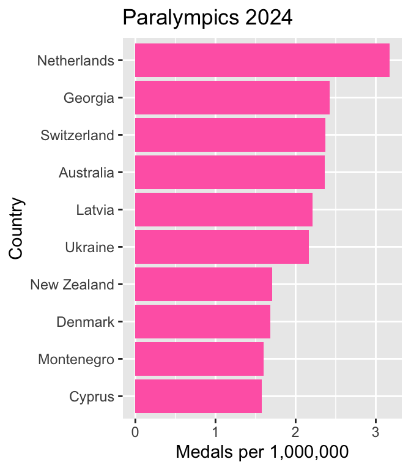

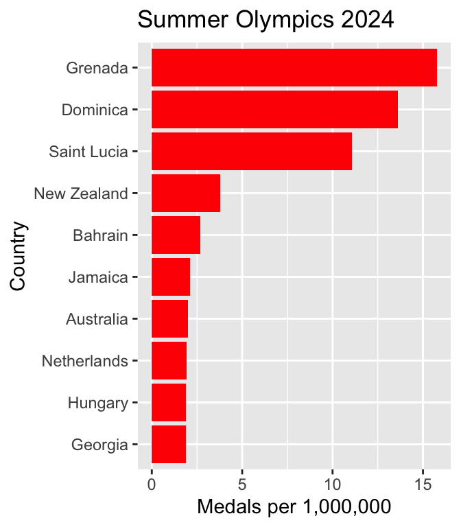

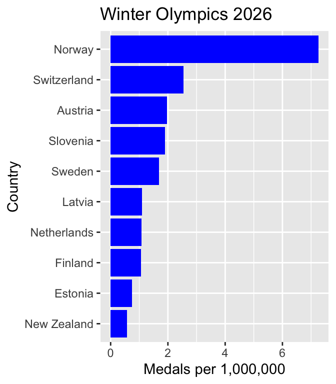

# How does the economic output of the country correlate with Medal Count?

This section focused only on the 2024 Summer Olympics and Paralympics.

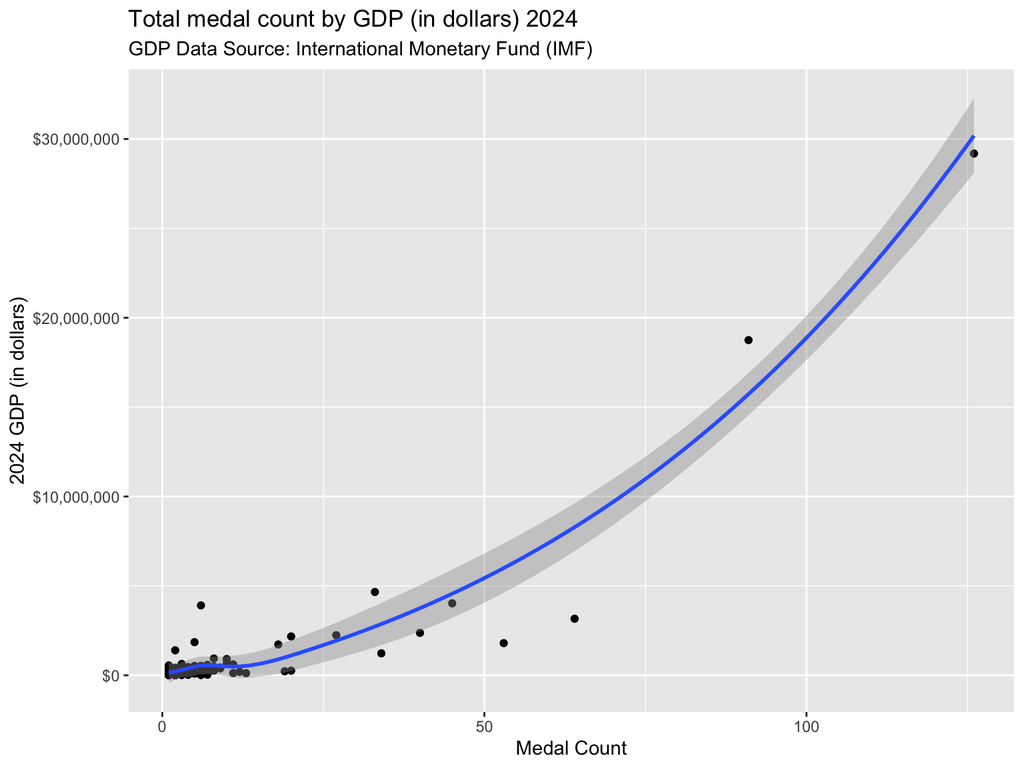

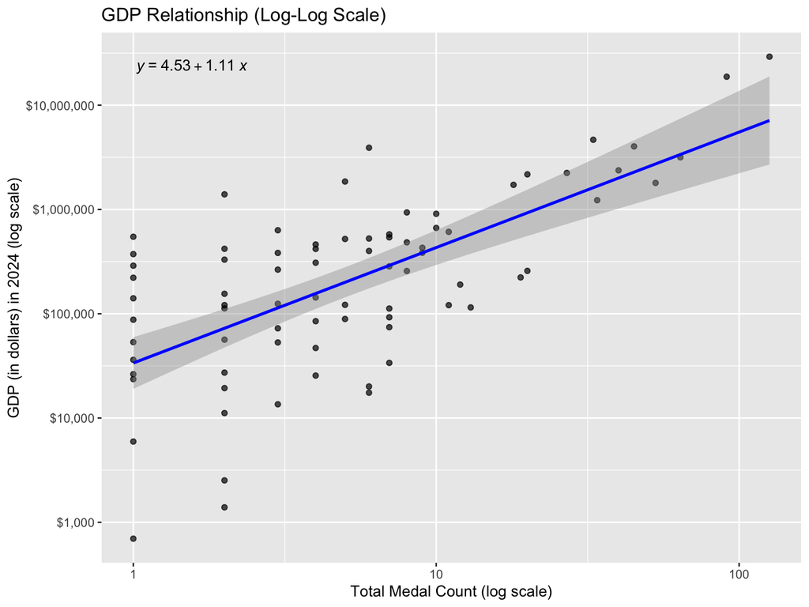

# Looking at GDP and Paralympics 2024

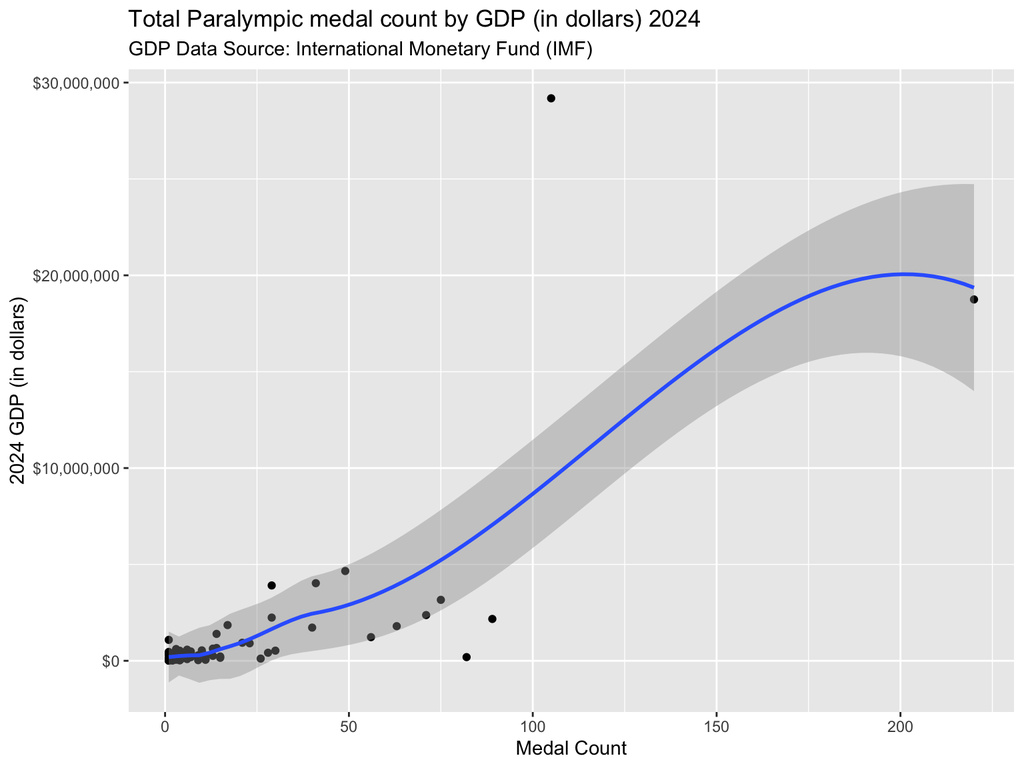

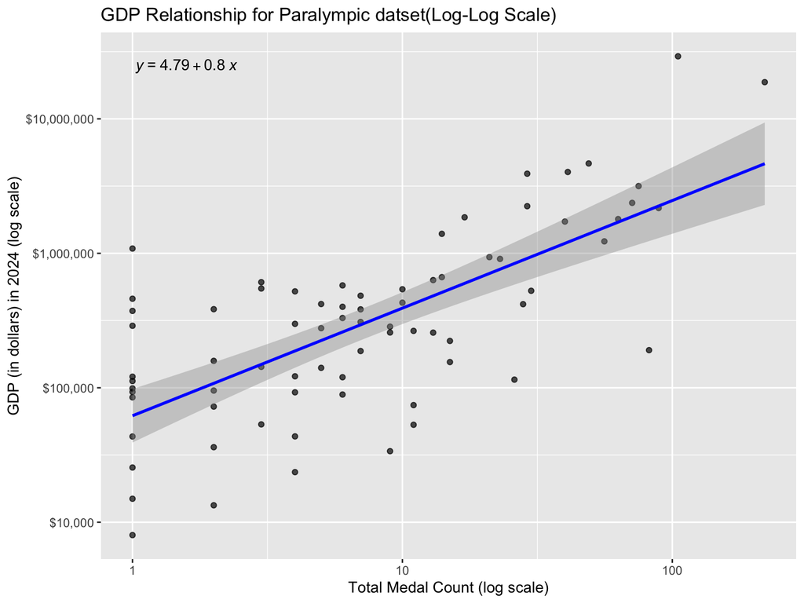